# Data Mining Analysis of Airbnb Rental Properties in Monserrat Buenos Aires Argentina

Putranegara Riauwindu

## Introduction

This GitHub repository contains data mining analysis on Airbnb rental properties in Monserrat, Buenos Aires, Argentina. The analysis focuses on delivering two key outputs to enhance decision-making for property owners and prospective tenants.

**1. Property Descriptive Analytics:**

- Property Overview: Summary statistics, visualizations, mapping, and word cloud analysis.
- Clustering: Grouping of properties based on similar characteristics.

**2. Property Predictive Analytics:**

- Price Prediction Model: A model to forecast property prices.
- Amenities Prediction Model: Predicting available amenities for a property.
- Property Feature Prediction Model: Predictive modeling of property features.
- Review Score Prediction Model: Forecasting review scores for properties.

These comprehensive data mining analysis results serve as valuable assets for property owners and prospective tenants in Monserrat. By leveraging data-driven insights, users can make informed decisions and enhance their ability to choose suitable rental properties.

Explore this repository to access the analysis code, datasets, and detailed documentation. Make data-driven choices for your property investments or find the perfect Airbnb rental in Monserrat with confidence.

## Importing Relevant Libraries

```r
library(tidyverse)
library(readr)
library(naniar)
library(jsonlite)
library(tidyr)
library(tidytext)
library(wordcloud)
library(leaflet)
library(scales)
library(ggbeeswarm)
library(rpart)
library(rpart.plot)
library(corrplot)
library(caret)
library(e1071)
library(forecast)
library(FNN)
```

## Importing Dataset

```r
master_data <- read_csv("buenos.csv")
data <- read_csv("buenos.csv")
```

## Step I: Data Preparation & Exploration

### 1. Missing Values (including Data Cleaning and Manipulation)

Please note that the explanations for what we did and why we did it are available at every steps below with the summary at the end of the steps.

1. Filtering to Monserrat Neighborhood

```r
data <- data %>%
  filter(neighbourhood_cleansed=='Monserrat')
```

2. Checking for Missing Value

```r
miss_var_summary(data)
```

```
## # A tibble: 75 × 3
##    variable                     n_miss pct_miss
##    <chr>                         <int>    <dbl>
##  1 neighbourhood_group_cleansed    902    100
##  2 bathrooms                       902    100
##  3 calendar_updated                902    100
##  4 license                         883     97.9
##  5 host_about                      392     43.5
##  6 neighborhood_overview           375     41.6
##  7 neighbourhood                   375     41.6
##  8 host_neighbourhood              356     39.5
##  9 host_location                   202     22.4
## 10 review_scores_accuracy          190     21.1
## # ℹ 65 more rows
```

3. Removing variables with missing value >50%: neighbourhood_group_cleansed, bathrooms,calendar_updated, and license

```r
data <- data%>%
  select(-neighbourhood_group_cleansed, -bathrooms, -calendar_updated, -license)
```

4. Checking for other variables that might not be useful for this particular analysis

```r
head(data)
```

```
## # A tibble: 6 × 71
##       id listing_url             scrape_id last_scraped source name  description
##    <dbl> <chr>                       <dbl> <date>       <chr>  <chr> <chr>
## 1 143663 https://www.airbnb.com…   2.02e13 2023-03-29   city … Apar… "<b>The sp…
## 2  16695 https://www.airbnb.com…   2.02e13 2023-03-29   city … DUPL… "<b>The sp…
## 3 148284 https://www.airbnb.com…   2.02e13 2023-03-29   city … Sunn… "Sunny apa…
## 4  23798 https://www.airbnb.com…   2.02e13 2023-03-29   city … STUN…  <NA>
## 5  31514 https://www.airbnb.com…   2.02e13 2023-03-29   city … BEAU… "The Duple…
## 6  42450 https://www.airbnb.com…   2.02e13 2023-03-29   city … Fren… "This refi…
## # ℹ 64 more variables: neighborhood_overview <chr>, picture_url <chr>,
## #   host_id <dbl>, host_url <chr>, host_name <chr>, host_since <date>,
## #   host_location <chr>, host_about <chr>, host_response_time <chr>,
## #   host_response_rate <chr>, host_acceptance_rate <chr>,
## #   host_is_superhost <lgl>, host_thumbnail_url <chr>, host_picture_url <chr>,
## #   host_neighbourhood <chr>, host_listings_count <dbl>,
## #   host_total_listings_count <dbl>, host_verifications <chr>, …
```

- Removing following variables from dataset:

listing_url, scrape_id, last_scraped, source, description, neighborhood_overview, picture_url, host_id, host_url, host_name, host_since, host_location, host_about, host_response_time, host_response_rate, host_acceptance_rate, host_is_superhost, host_thumbnail_url, host_picture_url, host_neighborhood, host_listings_count, host_total_listings_count, host_verifications, host_has_profile_pic, host_identify_verified, calendar_last_scraped, first_review, and last_review.

- Combining descriptive variable and the URL columns into its own dataframe that could later be LEFT JOIN using id column.
- Combining host information into its own dataframe that could later be LEFT JOIN using id column.

```r
# Removing non-essential variable from main dataset
data <- data %>%
  select(- listing_url, - scrape_id, - last_scraped, - source, - description, - neighborhood_overview, - picture_url, - host_id, - host_url, - host_name, - host_since, - host_location, - host_about, - host_response_time, - host_response_rate, - host_acceptance_rate, - host_is_superhost, - host_thumbnail_url, - host_picture_url, -host_neighbourhood, - host_listings_count, - host_total_listings_count, - host_verifications, - host_has_profile_pic, - host_identity_verified, - calendar_last_scraped, -calculated_host_listings_count, -calculated_host_listings_count_entire_homes, -calculated_host_listings_count_private_rooms, -calculated_host_listings_count_shared_rooms, -first_review, -last_review)

# Creating host related information dataset
host <- master_data %>%
  filter(neighbourhood_cleansed=="Monserrat") %>%
  select(id, host_id, host_url, host_name, host_since, host_location, host_about,
         host_response_time, host_response_rate, host_acceptance_rate, host_is_superhost,
         host_thumbnail_url, host_picture_url, host_neighbourhood, host_listings_count,
         host_total_listings_count, host_verifications, host_has_profile_pic, host_identity_verified,
         calculated_host_listings_count, calculated_host_listings_count_entire_homes,
         calculated_host_listings_count_private_rooms,
         calculated_host_listings_count_shared_rooms)

# Creating Description information dataset
desc <- master_data %>%
  filter(neighbourhood_cleansed=="Monserrat")%>%
  select(id, description, neighborhood_overview, picture_url, listing_url)
```

5. Checking for missing value in the main dataset

```r
miss_var_summary(data)
```

```
## # A tibble: 39 × 3
##    variable                    n_miss pct_miss
##    <chr>                        <int>    <dbl>
##  1 neighbourhood                  375    41.6
##  2 review_scores_accuracy         190    21.1
##  3 review_scores_cleanliness      190    21.1
##  4 review_scores_checkin          190    21.1
##  5 review_scores_communication    190    21.1
##  6 review_scores_location         190    21.1
##  7 review_scores_value            190    21.1
##  8 review_scores_rating           188    20.8
##  9 reviews_per_month              188    20.8
## 10 bedrooms                        88     9.76
## # ℹ 29 more rows
```

Based on the above information, below inferences and decisions were made

1. neighbourhood: this variable does not give any additional value to the overall analysis as this is a duplicate information from the “neighbourhood_cleansed”. This variable will be removed
2. all review scores: the missing observation related to all review scores will be removed review is something that is subjective based on the input of the user thus it would not be a wise decision to impute this as it will introduce bias to the dataset
3. reviews_per_month missing observation will be removed as imputing it might introduce bias to the dataset
4. bedrooms, beds, and bathroom_text missing observation will be removed as it is property specific and imputing the value might give a misleading the associated properly characteristics.

```r
# Removing neighbourhood column
data <- data %>%
  select (-neighbourhood)

# Removing missing observations from above-mentioned variables
data <- subset(data, complete.cases(review_scores_accuracy,
                                     review_scores_checkin,
                                     review_scores_cleanliness,
                                     review_scores_communication,
                                     review_scores_location,
                                     review_scores_value,
                                     review_scores_rating,
                                     reviews_per_month,
                                     bedrooms,
                                     beds,
                                     bathrooms_text))
```

6. Manipulating bathroom data

```r
# extract the numerical value from the bathrooms_text variable
data$bathrooms <- as.numeric(gsub("[^[:digit:]./]", "", data$bathrooms_text))

# create a new variable to indicate whether the bathroom is shared or not
data$shared_bathroom <- ifelse(grepl("shared", data$bathrooms_text, ignore.case = TRUE), "Yes", "No")

# handle cases where bathrooms_text is "shared bath" or missing
data$bathrooms[grepl("shared", data$bathrooms_text, ignore.case = TRUE) |
               is.na(data$bathrooms_text)] <- NA

# handle cases where bathrooms_text is "0 bath" or "0.5 bath"
data$bathrooms[data$bathrooms == 0] <- 0.5
data$bathrooms[data$bathrooms == 0.5 & grepl("shared", data$bathrooms_text, ignore.case = TRUE)] <- NA

# handle cases where bathrooms_text is "X shared bath" or "X.X shared bath"
data$bathrooms[grepl("shared", data$bathrooms_text, ignore.case = TRUE) &
               !grepl("0\\.5", data$bathrooms_text) &
               !is.na(data$bathrooms_text)] <- as.numeric(gsub("[^[:digit:]./]", "", data$bathrooms_text[grepl("shared", data$bathrooms_text, ignore.case = TRUE)]))

# replace missing values with the median number of bathrooms
data$bathrooms[is.na(data$bathrooms)] <- median(data$bathrooms, na.rm = TRUE)
```

7. Manipulating amenities data

```r
# split the string column into a list column
data$amenities_list <- lapply(data$amenities, jsonlite::fromJSON)

# specify the maximum length of the list
max_len <- max(lengths(data$amenities_list))

# pad shorter lists with NA values
data$amenities_list <- lapply(data$amenities_list, `length<-`, max_len)

# convert the list column to wide format
data <- unnest_wider(data, col = amenities_list, names_sep = "_")

# converting all amenities columns into categorical
for (i in 1:10) {
  col_name <- paste0("amenities_list_", i)
  data[[col_name]] <- as.factor(data[[col_name]])}
```

8. Merging the previously splitted dataset into new merged data

```r
merged_data <- left_join(data,host, by='id')
merged_data <- left_join(merged_data, desc, by='id')
```

9. Grouping the amenities for simplification

```r
merged_data$Kitchen <- apply(merged_data[, 41:107], 1, function(x) { ifelse(sum(grepl("Kitchen", x)) > 0, 1, 0) })
merged_data$Wifi <- apply(merged_data[, 41:107], 1, function(x) { ifelse(sum(grepl("Wifi", x)) > 0, 1, 0) })
merged_data$Air_conditioning <- apply(merged_data[, 41:107], 1, function(x) { ifelse(sum(grepl("Air conditioning", x)) > 0, 1, 0) })
merged_data$Elevator <- apply(merged_data[, 41:107], 1, function(x) { ifelse(sum(grepl("Elevator", x)) > 0, 1, 0) })
merged_data$Dishes_and_silverware <- apply(merged_data[, 41:107], 1, function(x) { ifelse(sum(grepl("Dishes and silverware", x)) > 0, 1, 0) })
merged_data$Washer <- apply(merged_data[, 41:107], 1, function(x) { ifelse(sum(grepl("Washer", x)) > 0, 1, 0) })
merged_data$Body_soap <- apply(merged_data[, 41:107], 1, function(x) { ifelse(sum(grepl("Body soap", x)) > 0, 1, 0) })
merged_data$Microwave <- apply(merged_data[, 41:107], 1, function(x) { ifelse(sum(grepl("Microwave", x)) > 0, 1, 0) })
merged_data$Paid_parking_off_premises <- apply(merged_data[, 41:107], 1, function(x) { ifelse(sum(grepl("Paid parking off premises", x)) > 0, 1, 0) })
merged_data$TV <- apply(merged_data[, 41:107], 1, function(x) { ifelse(sum(grepl("TV", x)) > 0, 1, 0) })
```

10. Grouping Availability information for simplification

The availability were binned into two variables

- short term: (availability 30 + availability 60 + availability 90)/3, if the value is more than mean of the short term column, then its 1 otherwise 0
- long term: availability 365. if the value is more the mean of the availability 365 column, then its 1, otherwise its 0

1 means that the property has the availability for that particular short or long term, while 0 is the otherwise.

Another manipulation in this part is that another two new columns were created to aid in the analysis which are:

- years: describing how many years has elapsed since the listing first listed on the AirBnB
- total_amenities; describing how many variants of amenities each listing have.

```r
merged_data <- merged_data %>%
  mutate(mean_short = (availability_30+availability_60+availability_90)/3) %>%
  mutate(short_term_availability = ifelse(mean_short<mean(mean_short), 0, 1)) %>%
  mutate(long_term_availability = ifelse(availability_365 < mean(availability_365), 0,1)) %>%
  mutate(start_date = as.Date(host_since)) %>%
  mutate(end_date = as.Date("2023-05-05")) %>%
  mutate(years = as.numeric(difftime(end_date, start_date)))%>%
  mutate(years = years/365) %>%
  mutate(total_amenities = Kitchen+Wifi+Air_conditioning+Elevator+Dishes_and_silverware+Washer
         +Body_soap+Microwave+Paid_parking_off_premises)
```

11. Housekeeping on host data, price data, and property/room type data

```r
# Remove "N/A" value in the host data
merged_data <- subset(merged_data, host_response_time != "N/A")
merged_data <- subset(merged_data, host_response_rate != "N/A")
merged_data <- subset(merged_data, host_acceptance_rate != "N/A")

# Converting host response rate and acceptance rate into numeric
merged_data$host_response_rate <- as.numeric(gsub("%", "", merged_data$host_response_rate))/100
merged_data$host_acceptance_rate <- as.numeric(gsub("%", "", merged_data$host_acceptance_rate))/100

# Preparing price data
merged_data$price <- gsub("\\$|,", "", merged_data$price)
merged_data$price <- as.numeric(merged_data$price)

# Converting room and property type data into categorical
merged_data$property_type <- as.factor(merged_data$property_type)
merged_data$room_type <- as.factor(merged_data$room_type)
```

The “N/A” value in the host_response_time and host_response_rate were decided to be removed due to its low proportion in the dataset. Imputing it might introduce bias.

12. Converting variables into categorical

```r
merged_data$room_type <- as.factor(merged_data$room_type)
merged_data$instant_bookable <- as.factor(merged_data$instant_bookable)
merged_data$shared_bathroom <- as.factor(merged_data$shared_bathroom)
merged_data$host_response_time <- as.factor(merged_data$host_response_time)
merged_data$host_is_superhost <- as.factor(merged_data$host_is_superhost)
merged_data$host_identity_verified <- as.factor(merged_data$host_identity_verified)
merged_data$Kitchen <- as.factor(merged_data$Kitchen)
merged_data$Wifi <- as.factor(merged_data$Wifi)
merged_data$Air_conditioning <- as.factor(merged_data$Air_conditioning)
merged_data$Elevator <- as.factor(merged_data$Elevator)
merged_data$Dishes_and_silverware <- as.factor(merged_data$Dishes_and_silverware)
merged_data$Washer <- as.factor(merged_data$Washer)
merged_data$Body_soap <- as.factor(merged_data$Body_soap)
merged_data$Microwave <- as.factor(merged_data$Microwave)
merged_data$Paid_parking_off_premises <- as.factor(merged_data$Paid_parking_off_premises)
merged_data$short_term_availability <- as.factor(merged_data$short_term_availability)
merged_data$long_term_availability <- as.factor(merged_data$long_term_availability)
```

13. Selecting columns that we want to focus on

```r
data_new <- merged_data %>%
  select(id, name, latitude, longitude, property_type, room_type, price,
         accommodates, bedrooms, beds,bathrooms,shared_bathroom, minimum_nights,
         maximum_nights, number_of_reviews, review_scores_rating, review_scores_accuracy,
         review_scores_cleanliness, review_scores_checkin,
         review_scores_communication, review_scores_location, review_scores_value,
         instant_bookable, Kitchen, Wifi, Air_conditioning, Elevator, Dishes_and_silverware,
         Washer, Body_soap, Microwave, Paid_parking_off_premises,
         total_amenities, short_term_availability,
         long_term_availability, years, host_id, host_response_time,
         host_response_rate, host_acceptance_rate, host_is_superhost, host_identity_verified,
         )
```

14. Exporting the data into csv format to be shared to the rest of the team member

```r
write.csv(data_new, file = "data_new.csv", row.names = FALSE)
```

TLDR:

We removed several variables that we believed will not add much value to the analysis that we are going to focus on. We also removed observations with “N/A” or missing value because we believe that it was not possible to impute the data without introducing significant bias. We also did some “feature engineering” on several variables to simplify the modeling and analysis.

### 2. Summary Statistics

Looking at the Airbnb data for Monserrat Neighborhood, it is interesting to know what are the:

- Price
- Bedrooms
- Bathrooms: Private and Shared
- Accommodates
- Overall Review Scores
- Total Amenities

based on each property room type. Below is the summary statistics for each of the variables.

1. Summary Statistics: Price

```r
price_stats <- data_new %>%
  group_by(room_type) %>%
  summarise(
    observation = n(),
    mean_price = mean(price, na.rm = TRUE),
    sd_price = sd(price, na.rm = TRUE),
    median_price = median(price, na.rm = TRUE),
    min_price = min(price, na.rm = TRUE),
    max_price = max(price, na.rm = TRUE))
price_stats
```

```
## # A tibble: 4 × 7
##   room_type     observation mean_price sd_price median_price min_price max_price
##   <fct>               <int>      <dbl>    <dbl>        <dbl>     <dbl>     <dbl>
## 1 Entire home/…         439     10242.   16226.        8076       1861    262857
## 2 Hotel room              7     12340.    3660.       13017       6390     16920
## 3 Private room          103      4610.    2213.        4142       2018     16642
## 4 Shared room            14      3317.    2611.        2682.       175     11596
```

2. Summary Statistics: Bathrooms Private

```r
bathrooms_private_stats <- data_new %>%
  filter(shared_bathroom=="No") %>%
  group_by(room_type) %>%
  summarise(
    observation = n(),
    mean_bathrooms = mean(bathrooms, na.rm = TRUE),
    sd_bathrooms = sd(bathrooms, na.rm = TRUE),
    median_bathrooms = median(bathrooms, na.rm = TRUE),
    min_bathrooms = min(bathrooms, na.rm = TRUE),
    max_bathrooms = max(bathrooms, na.rm = TRUE))
bathrooms_private_stats
```

```
## # A tibble: 3 × 7
##   room_type       observation mean_bathrooms sd_bathrooms median_bathrooms
##   <fct>                 <int>          <dbl>        <dbl>            <dbl>
## 1 Entire home/apt         439           1.15        0.460                1
## 2 Hotel room                4           1           0                    1
## 3 Private room             20           1.42        0.766                1
## # ℹ 2 more variables: min_bathrooms <dbl>, max_bathrooms <dbl>
```

2. Summary Statistics: Bathrooms Shared

```r
bathrooms_shared_stats <- data_new %>%
  filter(shared_bathroom=="Yes") %>%
  group_by(room_type) %>%
  summarise(
    observation = n(),
    mean_bathrooms = mean(bathrooms, na.rm = TRUE),
    sd_bathrooms = sd(bathrooms, na.rm = TRUE),
    median_bathrooms = median(bathrooms, na.rm = TRUE),
    min_bathrooms = min(bathrooms, na.rm = TRUE),
    max_bathrooms = max(bathrooms, na.rm = TRUE))
bathrooms_shared_stats
```

```
## # A tibble: 3 × 7
##   room_type    observation mean_bathrooms sd_bathrooms median_bathrooms
##   <fct>              <int>          <dbl>        <dbl>            <dbl>
## 1 Hotel room             3           2.67         1.15                2
## 2 Private room          83           2.08         2.05                1
## 3 Shared room           14           2.21         1.31                3
## # ℹ 2 more variables: min_bathrooms <dbl>, max_bathrooms <dbl>
```

3. Summary Statistics: Bedrooms

```r
bedrooms_stats <- data_new %>%
  group_by(room_type) %>%
  summarise(
    observation = n(),
    mean_bedrooms = mean(bedrooms, na.rm = TRUE),
    sd_bedrooms = sd(bedrooms, na.rm = TRUE),
    median_bedrooms = median(bedrooms, na.rm = TRUE),
    min_bedrooms = min(bedrooms, na.rm = TRUE),
    max_bedrooms = max(bedrooms, na.rm = TRUE))
bedrooms_stats
```

```
## # A tibble: 4 × 7
##   room_type   observation mean_bedrooms sd_bedrooms median_bedrooms min_bedrooms
##   <fct>             <int>         <dbl>       <dbl>           <dbl>        <dbl>
## 1 Entire hom…         439          1.33       0.647               1            1
## 2 Hotel room            7          1          0                   1            1
## 3 Private ro…         103          2.21       2.72                1            1
## 4 Shared room          14          1          0                   1            1
## # ℹ 1 more variable: max_bedrooms <dbl>
```

4. Summary Statistics: Accommodates

```r
accommodates_stats <- data_new %>%
  group_by(room_type) %>%
  summarise(
    observation = n(),
    mean_accommodates = mean(accommodates, na.rm = TRUE),
    sd_accommodates = sd(accommodates, na.rm = TRUE),
    median_accommodates = median(accommodates, na.rm = TRUE),
    min_accommodates = min(accommodates, na.rm = TRUE),
    max_accommodates = max(accommodates, na.rm = TRUE))
accommodates_stats
```

```
## # A tibble: 4 × 7
##   room_type    observation mean_accommodates sd_accommodates median_accommodates
##   <fct>              <int>             <dbl>           <dbl>               <dbl>
## 1 Entire home…         439              3.11           1.35                  3
## 2 Hotel room             7              2              0.577                 2
## 3 Private room         103              2.15           2.32                  2
## 4 Shared room           14              2.36           1.86                  1.5
## # ℹ 2 more variables: min_accommodates <dbl>, max_accommodates <dbl>
```

5. Summary Statistics: Overall Review Scores

```r
review_stats <- data_new %>%
  group_by(room_type) %>%
  summarise(
    observation = n(),
    mean_review = mean(review_scores_rating, na.rm = TRUE),
    sd_review= sd(review_scores_rating, na.rm = TRUE),
    median_review = median(review_scores_rating, na.rm = TRUE),
    min_review = min(review_scores_rating, na.rm = TRUE),
    max_review = max(review_scores_rating, na.rm = TRUE))
review_stats
```

```
## # A tibble: 4 × 7
##   room_type       observation mean_review sd_review median_review min_review
##   <fct>                 <int>       <dbl>     <dbl>         <dbl>      <dbl>
## 1 Entire home/apt         439        4.71     0.434          4.83          1
## 2 Hotel room                7        4.27     0.694          4.38          3
## 3 Private room            103        4.62     0.479          4.8           3
## 4 Shared room              14        4.74     0.422          5             4
## # ℹ 1 more variable: max_review <dbl>
```

6. Summary Statistics: Total Amenities

```r
amenities_stats <- data_new %>%
  group_by(room_type) %>%
  summarise(
    observation = n(),
    mean_amenities = mean(total_amenities, na.rm = TRUE),
    sd_amenities= sd(total_amenities, na.rm = TRUE),
    median_amenities = median(total_amenities, na.rm = TRUE),
    min_amenities = min(total_amenities, na.rm = TRUE),
    max_amenities = max(total_amenities, na.rm = TRUE))
amenities_stats
```

```
## # A tibble: 4 × 7
##   room_type       observation mean_amenities sd_amenities median_amenities
##   <fct>                 <int>          <dbl>        <dbl>            <dbl>
## 1 Entire home/apt         439           5.44        1.44                 5
## 2 Hotel room                7           5.86        0.378                6
## 3 Private room            103           4.37        1.28                 4
## 4 Shared room              14           4.36        1.34                 5
## # ℹ 2 more variables: min_amenities <dbl>, max_amenities <dbl>
```

Summary

Monserrat, a charming location for vacationers, offered an array of Airbnb properties for travelers. Among the options available, entire homes or apartments proved to be the most popular, far outnumbering private rooms and shared spaces. Surprisingly, hotel rooms came out as the most expensive option, while entire homes or apartments ranked a close second.

For those who value their privacy, a property that specifies a private bathroom is essential. Interestingly, all properties with private bathrooms had one bathroom per room type on average, while those with shared bathrooms had two. Private rooms were found to have the highest average number of bedrooms, with around two per room on average. On the other hand, entire homes or apartments offered the highest average number of accommodates, which was typically around three people.

When it came to amenities, hotel rooms triumphed with the highest mean of total amenities, closely followed by entire homes or apartments. Despite the differences in amenities, all room types shared a relatively similar mean review rating, indicating that the quality of the listings was consistent across the board.

With all these options to choose from, Monserrat promises an unforgettable experience for all types of travelers.

### 3. Data Visualization

Looking at the airbnb data for Monserrat Neighborhood, it is interesting to visually see what are the:

- Population
- Price
- Overall Review
- Amenities Count
- Price Trends on Different Accommodates

based on each property room type. Below is the summary statistics for each of the variables.

1. Room Type Population

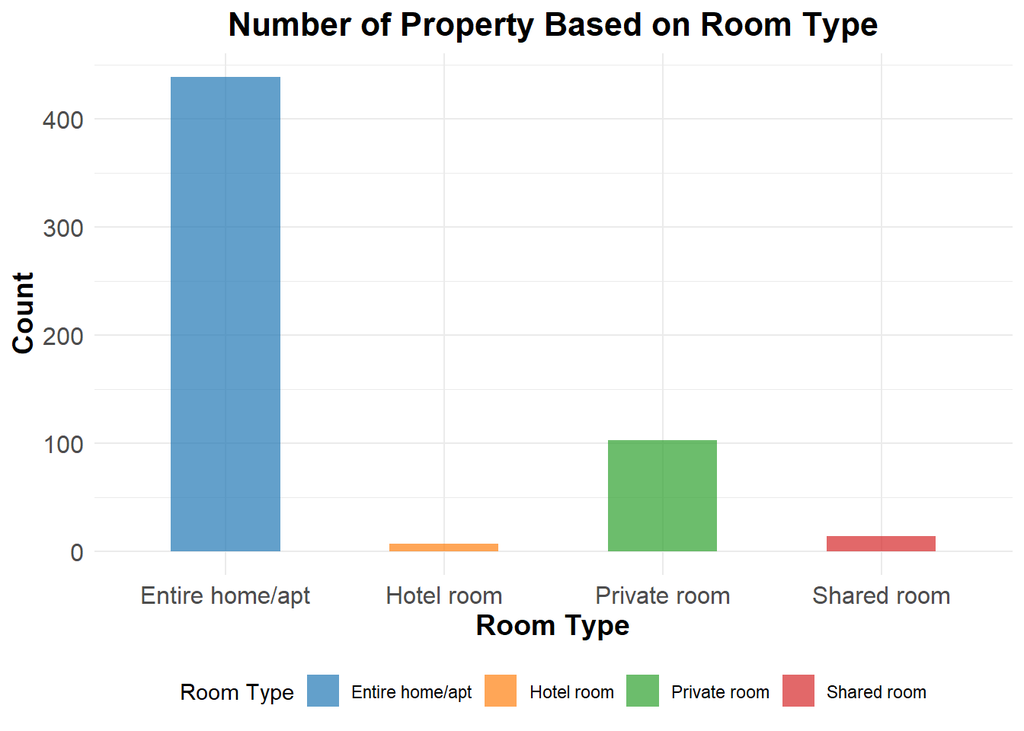

```r
ggplot(data_new, aes(x = room_type, y = ..count.., fill = room_type)) +
  geom_bar(alpha = 0.7, width = 0.5) +
  labs(x = "Room Type", y = "Count", fill = "Room Type") +
  scale_fill_manual(values = c("#1F77B4", "#FF7F0E", "#2CA02C", "#D62728")) +
  theme_minimal() +
  theme(plot.title = element_text(face = "bold", size = 16, hjust = 0.5),
        legend.position = "bottom",
        axis.title = element_text(face = "bold", size = 14),
        axis.text = element_text(size = 12)) +
  ggtitle("Number of Property Based on Room Type")
```

2. Room Type Price

note: there are two outliers price point for the “entire home/apt” room type (262,857 USD and 216,521 USD). Those two outliers were removed to show a better visualization

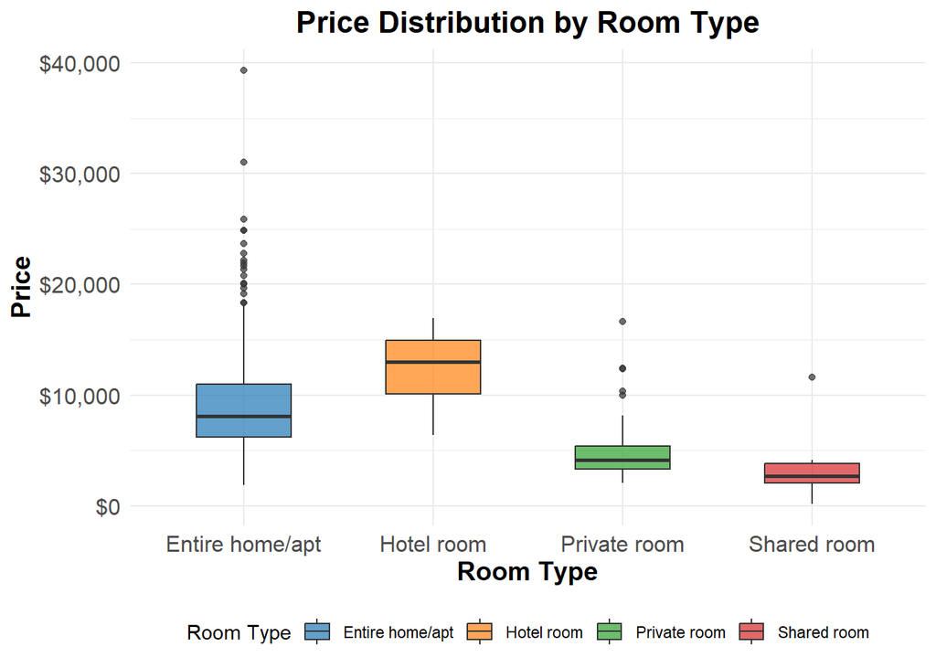

```r
# Remove two maximum values of price for entire home/apt
data_new_clean <- data_new %>%
  filter(!(room_type == "Entire home/apt" & price %in% tail(sort(price), 2)))

ggplot(data_new_clean, aes(x = room_type, y = price, fill = room_type)) +
  geom_boxplot(alpha = 0.7, width = 0.5) +
  labs(x = "Room Type", y = "Price", fill = "Room Type") +
  scale_fill_manual(values = c("#1F77B4", "#FF7F0E", "#2CA02C", "#D62728")) +
  scale_y_continuous(labels = dollar_format(prefix = "$")) +
  theme_minimal() +
  theme(plot.title = element_text(face = "bold", size = 16, hjust = 0.5),
        legend.position = "bottom",
        axis.title = element_text(face = "bold", size = 14),
        axis.text = element_text(size = 12)) +
  ggtitle("Price Distribution by Room Type")
```

3. Overall Review Score per Room Type

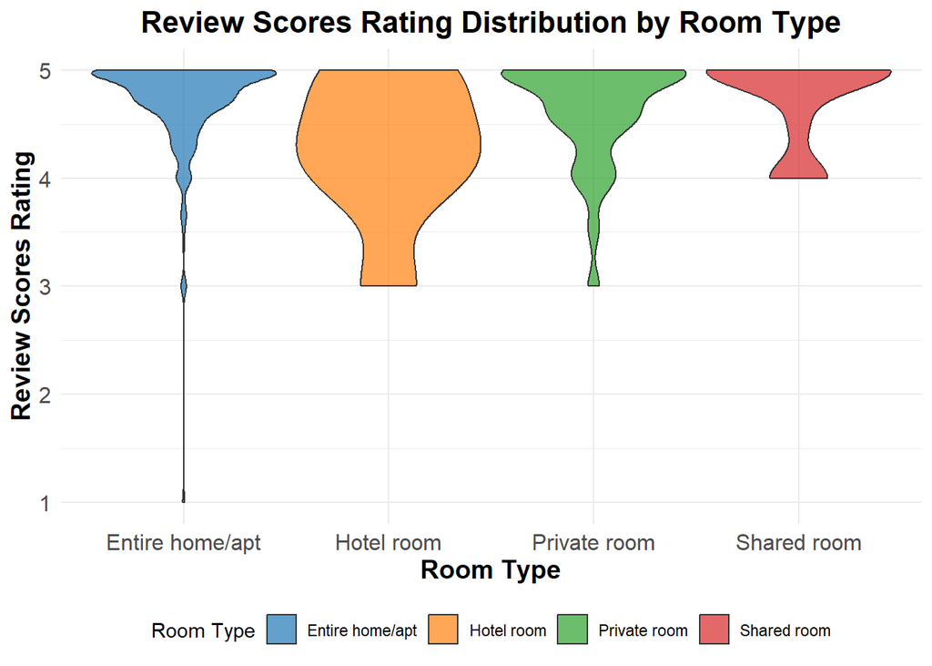

```r
ggplot(data_new, aes(x = room_type, y = review_scores_rating, fill = room_type)) +
  geom_violin(scale = "width", alpha = 0.7) +
  labs(x = "Room Type", y = "Review Scores Rating", fill = "Room Type") +
  scale_fill_manual(values = c("#1F77B4", "#FF7F0E", "#2CA02C", "#D62728")) +
  theme_minimal() +
  theme(plot.title = element_text(face = "bold", size = 16, hjust = 0.5),
        legend.position = "bottom",
        axis.title = element_text(face = "bold", size = 14),
        axis.text = element_text(size = 12)) +
  ggtitle("Review Scores Rating Distribution by Room Type")
```

4. Distribution of Amenities Number per Room Type

[figure not shown]

```r
# Calculate the sum of each amenity by room type
amenities_sum_by_roomtype <- data_new %>%
  select(room_type, Kitchen, Wifi, Air_conditioning, Elevator, Dishes_and_silverware, Washer, Body_soap, Microwave) %>%
  mutate(across(Kitchen: Microwave, as.numeric)) %>%
  group_by(room_type) %>%
  summarize_all(sum)

# Reshape data to long format for plotting
amenities_sum_by_roomtype_long <- amenities_sum_by_roomtype %>%
  pivot_longer(cols = -room_type, names_to = "amenity", values_to = "count") %>%
  arrange(room_type, desc(count))

# Create stacked bar plot
ggplot(amenities_sum_by_roomtype_long, aes(x = amenity, y = count, fill = room_type)) +
  geom_col() +
  scale_fill_manual(values = c("#F8766D", "#00BA38", "#619CFF", "#DA3B3A")) +
  labs(x = "Amenities", y = "Number of Listings", fill = "Room Type") +
  theme_minimal() +
  theme(plot.title = element_text(face = "bold", size = 16, hjust = 0.5),
        legend.position = "bottom",
        axis.title = element_text(face = "bold", size = 14),
        axis.text = element_text(size = 12),
        axis.text.x = element_text(angle = 45, hjust = 1)) +
  ggtitle("Amenities by Room Type")
```

5. Price Trend on Different Accommodates Capacity per Room Type

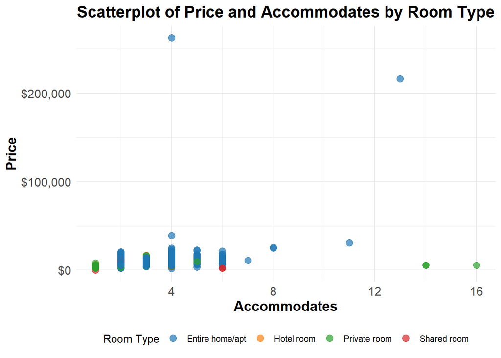

```r
my_colors <- c("#1F77B4", "#FF7F0E", "#2CA02C", "#D62728")

ggplot(data_new, aes(x = accommodates, y = price, color = room_type)) +
  geom_point(alpha = 0.7, size = 3) +
  scale_color_manual(values = my_colors) +
  scale_y_continuous(labels = dollar_format(prefix = "$")) +
  labs(x = "Accommodates", y = "Price", color = "Room Type") +
  theme_minimal() +
  theme(plot.title = element_text(face = "bold", size = 16, hjust = 0.5),
        legend.position = "bottom",
        axis.title = element_text(face = "bold", size = 14),
        axis.text = element_text(size = 12)) +
  ggtitle("Scatterplot of Price and Accommodates by Room Type")
```

Summary

Nestled in the stunning location of Monserrat, vacationers have an array of Airbnb properties to choose from. Dominating the market with around 400 listings, entire homes or apartments were the most popular option, followed by private rooms with around 100 listings. In contrast, the number of listings for hotel and shared rooms was relatively low.

When it comes to price, hotel rooms reign supreme as the most expensive option, followed by entire homes or apartments. Surprisingly, shared rooms were found to be the cheapest option. Entire homes or apartments boasted the broadest range of prices compared to the rest of the property room types, making them an attractive option for budget-conscious travelers.

All in all, Monserrat is an excellent location for vacationers, with Airbnb properties offering something for everyone.

### 4. Mapping

```r
m <- leaflet() %>% addTiles() %>% addCircles(data = data_new, lng= ~longitude , lat= ~latitude)%>% addProviderTiles(providers$JusticeMap.income)
m
```

[interactive chart not shown]

Description:

The neighborhood Monserrat is adjacent to the natural reservoir and Laguna de los Patos. Besides the nature, Monserrat has notable landmarks, such as the Casa Rosada and Plaza de Mayo, where the first is the presidential palace of Argentina and serves as the executive office of the President and the second is a historic public square that has been the site of many important political events in Argentina’s history.

### 5. Word Cloud

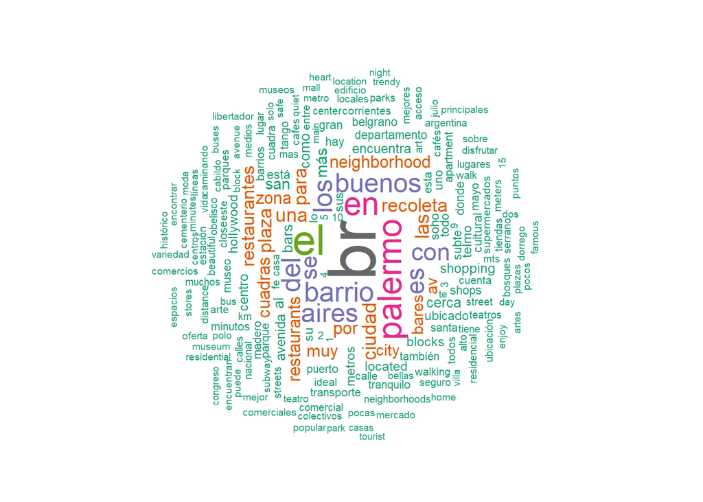

```r
# Split neighborhood_overview column into words and create a new dataframe
words <- master_data %>%
  select(neighborhood_overview) %>%
  unnest_tokens(word, neighborhood_overview)

# Create a custom list of stop words
custom_stopwords <- c(stop_words$word, "de", "la")

# Remove stop words and create a word frequency table
word_freq <- words %>%
  anti_join(stop_words, by = "word") %>%
  anti_join(data.frame(word = custom_stopwords), by = "word") %>%
  count(word, sort = TRUE)
# Set the size of the graphics device
options(repr.plot.width = 8, repr.plot.height = 8)

# Generate a word cloud
wordcloud(words = word_freq$word, freq = word_freq$n, min.freq = 1,
          max.words = 200, random.order = FALSE, rot.per = 0.5,
          colors = brewer.pal(8, "Dark2"))
```

The words in the word cloud are all related to the neighborhoods and landmarks in Buenos Aires, and their prominence in the word cloud can provide insights into the most frequent and important words in the neighborhood overview column of the Buenos Aires Airbnb dataset.

“Br” is likely to stand for “Barrio” or “neighborhood” in Spanish, and its prominence in the word cloud suggests that the neighborhood overview column frequently mentions different neighborhoods in Buenos Aires. “San” is an honorific title used in place names, and its appearance in the word cloud suggests that the neighborhood overview column may include references to different streets, districts, or landmarks with this title.

“Telmo” refers to the San Telmo neighborhood in Buenos Aires, which is known for its historic architecture, tango culture, and antique markets. Its appearance in the word cloud suggests that the neighborhood overview column may include descriptions of this neighborhood and its characteristics.

“Buenos” and “Aires” refer to the city of Buenos Aires, which is the capital of Argentina and one of the largest cities in South America. The appearance of these terms in the word cloud suggests that the neighborhood overview column may include descriptions of different neighborhoods and landmarks within the city.

“Mayo” refers to the Plaza de Mayo, which is a public square in the heart of Buenos Aires that is known for its historical and political significance. Its appearance in the word cloud suggests that the neighborhood overview column may include descriptions of this landmark and its role in the city’s history.

“Plaza” refers to public squares and plazas, which are common features in many neighborhoods in Buenos Aires. Its appearance in the word cloud suggests that the neighborhood overview column may include descriptions of different plazas and their characteristics.

## Step II: Prediction

The multiple regression model were constructed in the following steps.

1. Defining data

```r
MLR <- data_new
```

2. Convert the price variable using a log transformation

```r
MLR$price <- log(MLR$price)
```

3. Checking the uniqueness of the categorical variables.

By using the length() and unique() functions, we were able to identify the unique values of the categorical variable in the dataset. Based on the results, we have decided to remove several variables, namely id, host_id, name, latitude, and longitude from the dataset used for multiple linear regression (MLR) because of its irrelevancy to the MLR.

Furthermore, the property_type variable is a subtype of the room_type variable, and as such, it will also be removed.

```r
# Looking for number of unique value
length(unique(MLR$id))
```

```
## [1] 563
```

```r
length(unique(MLR$host_id))
```

```
## [1] 352
```

```r
length(unique(MLR$name))
```

```
## [1] 536
```

```r
length(unique(MLR$latitude))
```

```
## [1] 428
```

```r
length(unique(MLR$longitude))
```

```
## [1] 464
```

```r
length(unique(MLR$property_type))
```

```
## [1] 22
```

```r
length(unique(MLR$room_type))
```

```
## [1] 4
```

```r
length(unique(MLR$host_response_time))
```

```
## [1] 4
```

```r
# Removing the id, host_id, name, property_type, latitude, and longitude variable
MLR_clean <- subset(MLR, select=c(-id, -host_id, -name, -property_type, -latitude, -longitude))
```

4. Check the numeric variables’ correlation.

According to the results below, there are some variables that have relationship value >= 0.80: review_scores_rating & review_scores_accuracy, review_scores_rating & review_scores_value, and review_scores_accuracy & review_scores_value. Therefore, the review_scores_rating and review_scores_value variable will be removed from the dataset.

```r
library(corrplot)

# Calculating correlation between numeric variables
Corr <- cor(MLR_clean %>%
              select(c(accommodates, bedrooms, beds,
                       minimum_nights, maximum_nights,number_of_reviews,
                       review_scores_rating, review_scores_accuracy,
                       review_scores_cleanliness,review_scores_checkin,
                       review_scores_communication, review_scores_location,
                       review_scores_value, bathrooms, host_response_rate,
                       host_acceptance_rate, years)))
print(Corr)
```

```
##                             accommodates    bedrooms         beds
## accommodates                  1.00000000  0.39163873  0.776193337
## bedrooms                      0.39163873  1.00000000  0.531683944
## beds                          0.77619334  0.53168394  1.000000000
## minimum_nights               -0.13467965  0.17777513 -0.027669107
## maximum_nights                0.10563102  0.04177133  0.103623324
## number_of_reviews             0.04056428 -0.06457375  0.011063160
## review_scores_rating          0.02338411 -0.03305670 -0.025240309
## review_scores_accuracy        0.04624737 -0.03039344 -0.016314203
## review_scores_cleanliness     0.03412964 -0.06843784 -0.038610731
## review_scores_checkin         0.07016071  0.03541220  0.032680840
## review_scores_communication   0.07481748  0.02091280  0.046527560
## review_scores_location        0.01134373  0.02137466  0.031129775
## review_scores_value           0.05199863 -0.06058039  0.004536392
## bathrooms                     0.35909931  0.53828307  0.529161985
## host_response_rate            0.02777254 -0.02327931 -0.005885384
## host_acceptance_rate         -0.05074998 -0.05396403 -0.118515085
## years                         0.06097251  0.02816177  0.008185991
##                             minimum_nights maximum_nights number_of_reviews
## accommodates                  -0.134679647    0.105631016        0.04056428
## bedrooms                       0.177775127    0.041771334       -0.06457375
## beds                          -0.027669107    0.103623324        0.01106316
## minimum_nights                 1.000000000    0.103833378       -0.11052285
## maximum_nights                 0.103833378    1.000000000        0.03490829
## number_of_reviews             -0.110522847    0.034908288        1.00000000
## review_scores_rating          -0.003509136    0.022874314        0.06583003
## review_scores_accuracy        -0.001719427    0.030143104        0.10748644
## review_scores_cleanliness     -0.106790913    0.010408507        0.10563770
## review_scores_checkin         -0.019165431   -0.020121012        0.08515405
## review_scores_communication    0.016305678    0.071009596        0.07786747
## review_scores_location         0.055976142    0.004447184        0.07514351
## review_scores_value           -0.058117135    0.061768776        0.10479946
## bathrooms                      0.145787850    0.134600981       -0.04965522
## host_response_rate            -0.040275899    0.043639074        0.09637063
## host_acceptance_rate          -0.072882698   -0.066730768        0.11985212
## years                          0.114052990    0.030606622        0.18649473
##                             review_scores_rating review_scores_accuracy
## accommodates                         0.023384108            0.046247367
## bedrooms                            -0.033056704           -0.030393437
## beds                                -0.025240309           -0.016314203
```

[output cut: 71 more lines]

```
## beds                                -0.118515085  0.008185991
## minimum_nights                      -0.072882698  0.114052990
## maximum_nights                      -0.066730768  0.030606622
## number_of_reviews                    0.119852122  0.186494732
## review_scores_rating                 0.077495718  0.036039269
## review_scores_accuracy               0.116594755  0.035634714
## review_scores_cleanliness            0.160307863  0.043807187
## review_scores_checkin                0.096364374  0.050632067
## review_scores_communication         -0.016170611  0.109420548
## review_scores_location               0.003187999  0.052420460
## review_scores_value                  0.075671278 -0.009963601
## bathrooms                           -0.145416330  0.023395789
## host_response_rate                   0.439467106  0.004264235
## host_acceptance_rate                 1.000000000 -0.009850326
## years                               -0.009850326  1.000000000
```

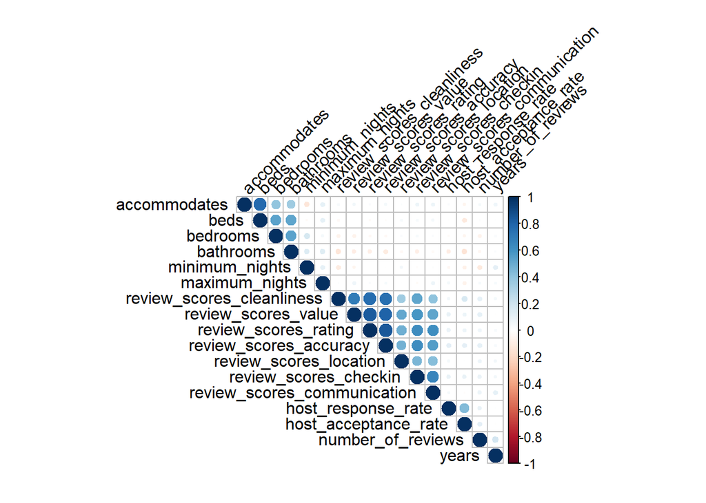

```r
# Plotting the correlation
corrplot(Corr, type = "upper", order = "hclust",
         tl.col = "black", tl.srt = 45)
```

```r
# Removing the review_scores_rating and review_scores_value variable
MLR_fix <- subset(MLR_clean, select=c(-review_scores_rating, -review_scores_value))
```

5. Data Partioning.